# HARPrediction

Nicole Homeier

11/1/2017

# HAR Prediction Exercise for the PML Course

```r
library(caret)
library(randomForest)
options(warn=-1)
```

First read the data in and remove set up variables that can’t be used for prediction.

```r
ds = read.csv("pml-training.csv")
test = read.csv("pml-testing.csv")
ds = ds[,-(1:7)]
```

had some trouble with numbers read in as factors due to missing values, so do this

```r
nds = ds
for (i in 1:(ncol(ds)-1)){ #skip the classe var
    if (class(ds[,i])=="factor"){nds[,i] = as.numeric(as.character(ds[,i]),verbose=FALSE)}
}
```

check for many missing values and remove

```r
ctna = sapply(ds,function(x) sum(is.na(x)))
nds = ds[,-which(ctna>5000)]
namesnds = names(ds)[which(ctna>5000)]
```

check out the test set, no use in predicting on variable that aren’t available in the test set

```r
ctnatest = sapply(test, function(x) sum(is.na(x)))
namestest = names(test)[which(ctnatest==0)]
cnds = nds[,which(names(nds) %in% namestest)]
cnds$classe = nds$classe
```

now have a better set of variables for fitting, but we can do better check where correlation between predictors is high, remove when needed

```r
M = cor(cnds[,-ncol(cnds)])
highcorr=which(M>.8 & M <1,arr.ind=T)
names(cnds)[highcorr[,2]]
```

```
##  [1] "roll_belt"        "roll_belt"        "roll_belt"
##  [4] "yaw_belt"         "total_accel_belt" "total_accel_belt"
##  [7] "accel_belt_x"     "accel_belt_y"     "accel_belt_y"
## [10] "magnet_belt_x"    "accel_arm_x"      "magnet_arm_x"
## [13] "magnet_arm_y"     "magnet_arm_z"     "pitch_dumbbell"
## [16] "yaw_dumbbell"     "gyros_dumbbell_z" "accel_dumbbell_x"
## [19] "accel_dumbbell_z" "gyros_forearm_y"  "gyros_forearm_z"
## [22] "gyros_forearm_z"
```

```r
names(highcorr[,1])
```

```
##  [1] "yaw_belt"         "total_accel_belt" "accel_belt_y"
##  [4] "roll_belt"        "roll_belt"        "accel_belt_y"
##  [7] "magnet_belt_x"    "roll_belt"        "total_accel_belt"
## [10] "accel_belt_x"     "magnet_arm_x"     "accel_arm_x"
## [13] "magnet_arm_z"     "magnet_arm_y"     "accel_dumbbell_x"
## [16] "accel_dumbbell_z" "gyros_forearm_z"  "pitch_dumbbell"
## [19] "yaw_dumbbell"     "gyros_forearm_z"  "gyros_dumbbell_z"
## [22] "gyros_forearm_y"
```

```r
dropvars = c("roll_belt","accel_belt_y","magnet_belt_x","gyros_forearm_z","magnet_arm_x","accel_dumbbell_x","magnet_arm_y","accel_dumbbell_z")
dpts = which(names(cnds) %in% dropvars)
cnds = cnds[,-dpts]
```

do a glm fit to get rid of the remaining non-important “predictors”

```r
glmfit = glm(classe~.,data=cnds,family=binomial)
summary(glmfit)
```

```
##
## Call:
## glm(formula = classe ~ ., family = binomial, data = cnds)
##
## Deviance Residuals:
##     Min       1Q   Median       3Q      Max
## -3.3374  -0.1575   0.1051   0.3627   4.4047
##
## Coefficients:
##                        Estimate Std. Error z value Pr(>|z|)
## (Intercept)           5.460e+01  3.177e+00  17.183  < 2e-16 ***
## pitch_belt           -2.164e-01  1.450e-02 -14.921  < 2e-16 ***
## yaw_belt             -1.566e-01  4.936e-03 -31.719  < 2e-16 ***
## total_accel_belt      1.029e-01  3.130e-02   3.288 0.001009 **
## gyros_belt_x          1.853e+00  3.251e-01   5.702 1.18e-08 ***
## gyros_belt_y          7.284e-01  9.183e-01   0.793 0.427647
## gyros_belt_z          9.179e-01  2.384e-01   3.850 0.000118 ***
## accel_belt_x          9.240e-03  5.504e-03   1.679 0.093179 .
## accel_belt_z         -1.154e-01  4.173e-03 -27.648  < 2e-16 ***
## magnet_belt_y        -6.860e-02  4.173e-03 -16.439  < 2e-16 ***
## magnet_belt_z         6.964e-02  2.439e-03  28.557  < 2e-16 ***
## roll_arm              4.454e-03  5.022e-04   8.869  < 2e-16 ***
## pitch_arm            -9.066e-03  1.071e-03  -8.469  < 2e-16 ***
## yaw_arm               5.874e-03  4.280e-04  13.725  < 2e-16 ***
## total_accel_arm      -6.329e-03  3.601e-03  -1.757 0.078863 .
## gyros_arm_x           1.486e-01  4.342e-02   3.423 0.000618 ***
## gyros_arm_y          -2.662e-02  1.070e-01  -0.249 0.803541
## gyros_arm_z          -3.563e-04  8.381e-02  -0.004 0.996608
## accel_arm_x          -1.114e-02  5.169e-04 -21.547  < 2e-16 ***
## accel_arm_y          -1.257e-02  1.165e-03 -10.790  < 2e-16 ***
## accel_arm_z           2.707e-02  1.063e-03  25.463  < 2e-16 ***
## magnet_arm_z         -1.244e-02  4.505e-04 -27.608  < 2e-16 ***
## roll_dumbbell         3.295e-03  7.339e-04   4.490 7.13e-06 ***
## pitch_dumbbell        6.676e-05  1.406e-03   0.047 0.962133
## yaw_dumbbell         -1.955e-02  6.673e-04 -29.292  < 2e-16 ***
## total_accel_dumbbell  6.686e-02  6.615e-03  10.107  < 2e-16 ***
## gyros_dumbbell_x      6.559e-01  1.094e-01   5.998 2.00e-09 ***
## gyros_dumbbell_y      6.895e-01  7.668e-02   8.992  < 2e-16 ***
## gyros_dumbbell_z      2.536e-01  6.820e-02   3.719 0.000200 ***
## accel_dumbbell_y     -6.462e-05  1.318e-03  -0.049 0.960902
```

[output cut: 10 more lines]

```
## accel_forearm_y       1.741e-03  4.434e-04   3.926 8.62e-05 ***
## accel_forearm_z      -1.019e-02  5.145e-04 -19.807  < 2e-16 ***
## magnet_forearm_x     -2.211e-03  2.883e-04  -7.671 1.71e-14 ***
## magnet_forearm_y     -1.421e-03  1.818e-04  -7.813 5.58e-15 ***
## magnet_forearm_z      6.625e-05  1.622e-04   0.408 0.683027
## ---
## Signif. codes:  0 '***' 0.001 '**' 0.01 '*' 0.05 '.' 0.1 ' ' 1
##
## (Dispersion parameter for binomial family taken to be 1)
##
##     Null deviance: 23430  on 19621  degrees of freedom
## Residual deviance: 10088  on 19577  degrees of freedom
## AIC: 10178
##
## Number of Fisher Scoring iterations: 7
```

```r
dropvars = c("gyros_belt_y","gyros_arm_x","gyros_arm_z","pitch_dumbbell","accel_dumbbell_y","magnet_forearm_z")
dpts = which(names(cnds) %in% dropvars)
cnds = cnds[,-dpts]
```

write out in case want to start here later

```r
write.csv(cnds,"reduced-pml-training.csv",row.names=F)
```

now create some training and testing data and train some models

```r
set.seed(3233)
inTrain = createDataPartition(cnds$classe,p=.6,list=TRUE)[[1]]
training = cnds[inTrain,]
testing = cnds[-inTrain,]
```

```r
rpart.grid = expand.grid(cp=seq(0,0.01,0.0005))
rpartfit = train(classe~.,data=training,method="rpart",tuneGrid=rpart.grid,trControl=trainControl(method="cv"))
predrpart = predict(rpartfit,newdata=testing)
confusionMatrix(predrpart,testing$classe)
```

```
## Confusion Matrix and Statistics
##
##           Reference
## Prediction    A    B    C    D    E
##          A 2105   64   10   17   14
##          B   60 1298   35   27   33
##          C   13   82 1258   35   16
##          D   26   31   43 1168   21
##          E   28   43   22   39 1358
##
## Overall Statistics
##
##                Accuracy : 0.916
##                  95% CI : (0.9097, 0.9221)
##     No Information Rate : 0.2845
##     P-Value [Acc > NIR] : < 2.2e-16
##
##                   Kappa : 0.8938
##  Mcnemar's Test P-Value : 0.0001399
##
## Statistics by Class:
##
##                      Class: A Class: B Class: C Class: D Class: E
## Sensitivity            0.9431   0.8551   0.9196   0.9082   0.9417
## Specificity            0.9813   0.9755   0.9775   0.9816   0.9794
## Pos Pred Value         0.9525   0.8933   0.8960   0.9061   0.9114
## Neg Pred Value         0.9775   0.9656   0.9829   0.9820   0.9868
## Prevalence             0.2845   0.1935   0.1744   0.1639   0.1838
## Detection Rate         0.2683   0.1654   0.1603   0.1489   0.1731
## Detection Prevalence   0.2817   0.1852   0.1789   0.1643   0.1899
## Balanced Accuracy      0.9622   0.9153   0.9485   0.9449   0.9606
```

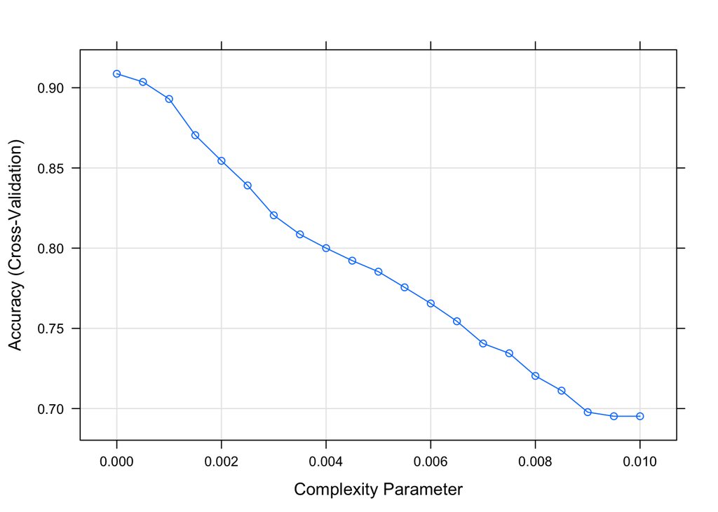

```r
plot(rpartfit)
```

```r
ldafit = train(classe~.,data=training,method="lda",preProcess=c("center","scale"),trControl=trainControl(method="cv"))
predlda = predict(ldafit,newdata=testing)
confusionMatrix(predlda,testing$classe)
```

```
## Confusion Matrix and Statistics
##
##           Reference
## Prediction    A    B    C    D    E
##          A 1653  273  135   66   51
##          B  126  873  139   75  252
##          C  244  169  847  170  172
##          D  189   87  205  887  152
##          E   20  116   42   88  815
##
## Overall Statistics
##
##                Accuracy : 0.6468
##                  95% CI : (0.6361, 0.6574)
##     No Information Rate : 0.2845
##     P-Value [Acc > NIR] : < 2.2e-16
##
##                   Kappa : 0.5542
##  Mcnemar's Test P-Value : < 2.2e-16
##
## Statistics by Class:
##
##                      Class: A Class: B Class: C Class: D Class: E
## Sensitivity            0.7406   0.5751   0.6192   0.6897   0.5652
## Specificity            0.9065   0.9064   0.8835   0.9035   0.9585
## Pos Pred Value         0.7590   0.5959   0.5287   0.5836   0.7539
## Neg Pred Value         0.8978   0.8989   0.9166   0.9369   0.9073
## Prevalence             0.2845   0.1935   0.1744   0.1639   0.1838
## Detection Rate         0.2107   0.1113   0.1080   0.1131   0.1039
## Detection Prevalence   0.2776   0.1867   0.2042   0.1937   0.1378
## Balanced Accuracy      0.8235   0.7408   0.7513   0.7966   0.7618
```

```r
knn.grid = expand.grid(k=seq(3,12,2))
knnfit = train(classe~.,data=training,method="knn",preProcess=c("center","scale"),tuneGrid=knn.grid,trControl=trainControl(method="cv"))
predknn = predict(knnfit,newdata=testing)
confusionMatrix(predknn,testing$classe)
```

```
## Confusion Matrix and Statistics
##
##           Reference
## Prediction    A    B    C    D    E
##          A 2210   27    6    1    0
##          B   13 1446    9    3   13
##          C    3   35 1326   34    2
##          D    5    6   26 1243    1
##          E    1    4    1    5 1426
##
## Overall Statistics
##
##                Accuracy : 0.9751
##                  95% CI : (0.9715, 0.9785)
##     No Information Rate : 0.2845
##     P-Value [Acc > NIR] : < 2.2e-16
##
##                   Kappa : 0.9686
##  Mcnemar's Test P-Value : 0.0001371
##
## Statistics by Class:
##
##                      Class: A Class: B Class: C Class: D Class: E
## Sensitivity            0.9901   0.9526   0.9693   0.9666   0.9889
## Specificity            0.9939   0.9940   0.9886   0.9942   0.9983
## Pos Pred Value         0.9848   0.9744   0.9471   0.9703   0.9923
## Neg Pred Value         0.9961   0.9887   0.9935   0.9935   0.9975
## Prevalence             0.2845   0.1935   0.1744   0.1639   0.1838
## Detection Rate         0.2817   0.1843   0.1690   0.1584   0.1817
## Detection Prevalence   0.2860   0.1891   0.1784   0.1633   0.1832
## Balanced Accuracy      0.9920   0.9733   0.9789   0.9804   0.9936
```

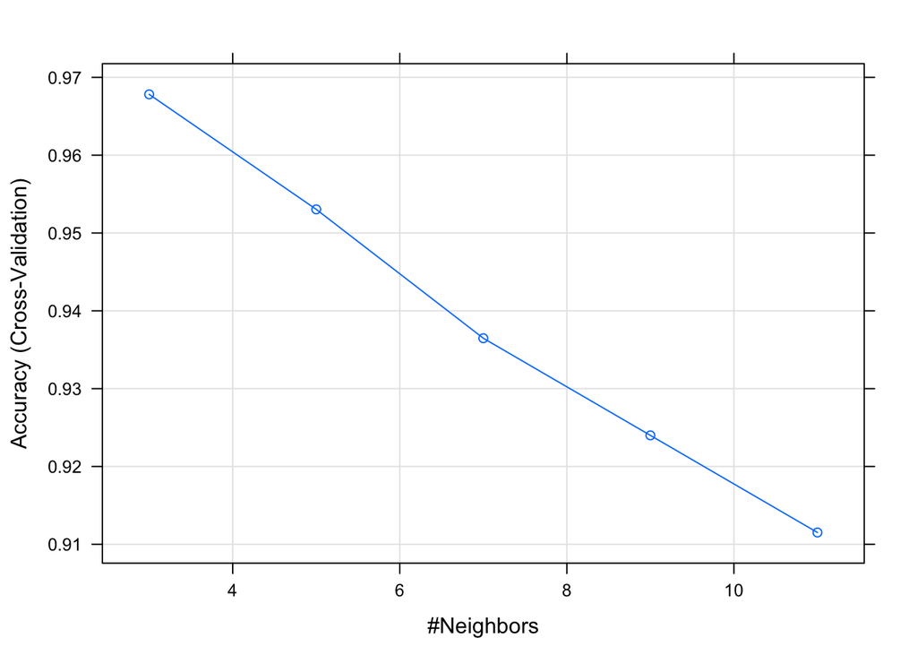

```r
plot(knnfit)
```

```r
rffit = randomForest(classe~.,data=training)
predrf = predict(rffit,newdata=testing)
confusionMatrix(predrf,testing$classe)
```

```
## Confusion Matrix and Statistics
##
##           Reference
## Prediction    A    B    C    D    E
##          A 2227    3    0    0    0
##          B    5 1508    4    0    0
##          C    0    7 1358   13    1
##          D    0    0    6 1271    0
##          E    0    0    0    2 1441
##
## Overall Statistics
##
##                Accuracy : 0.9948
##                  95% CI : (0.9929, 0.9962)
##     No Information Rate : 0.2845
##     P-Value [Acc > NIR] : < 2.2e-16
##
##                   Kappa : 0.9934
##  Mcnemar's Test P-Value : NA
##
## Statistics by Class:
##
##                      Class: A Class: B Class: C Class: D Class: E
## Sensitivity            0.9978   0.9934   0.9927   0.9883   0.9993
## Specificity            0.9995   0.9986   0.9968   0.9991   0.9997
## Pos Pred Value         0.9987   0.9941   0.9848   0.9953   0.9986
## Neg Pred Value         0.9991   0.9984   0.9985   0.9977   0.9998
## Prevalence             0.2845   0.1935   0.1744   0.1639   0.1838
## Detection Rate         0.2838   0.1922   0.1731   0.1620   0.1837
## Detection Prevalence   0.2842   0.1933   0.1758   0.1628   0.1839
## Balanced Accuracy      0.9986   0.9960   0.9947   0.9937   0.9995
```

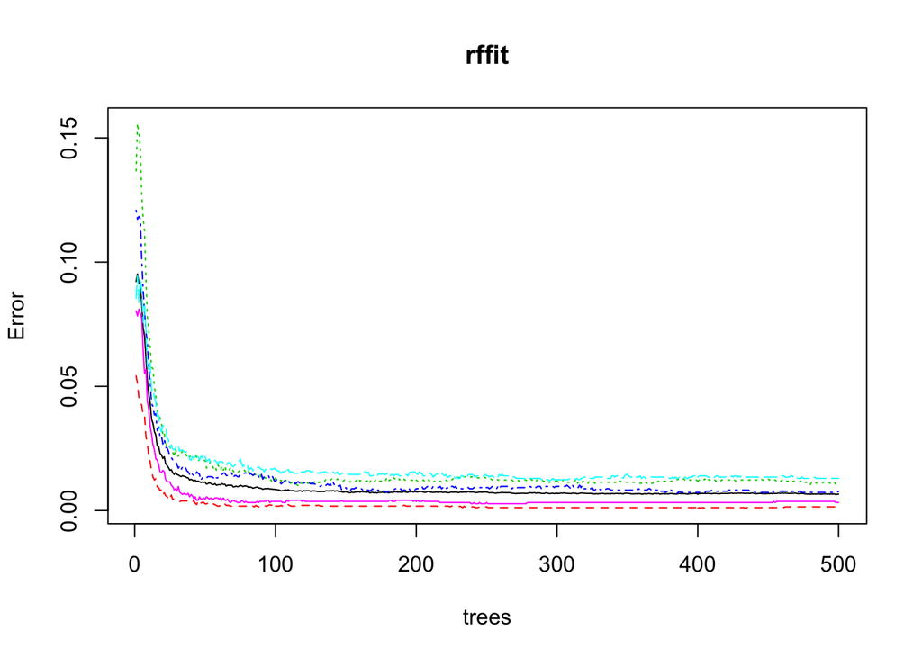

can see that don’t need more than 200 trees

```r
rffit$mtry
```

```
## [1] 6
```

it would appear that a random forest approach gives the best results, but outside of this exercise it would make me worry about overfitting. Here I’ve held back 40% of the data so unlikely. Now do some estimation so see how expectations for accuracy on the 20 test set values.

```r
inTrain = createDataPartition(cnds$classe,p=(1-20/nrow(cnds)),list=TRUE)[[1]]
training = cnds[inTrain,]
testing = cnds[-inTrain,]
```

```r
finalfit = randomForest(classe~.,data=training,mtry=6,ntree=200,keep.forest=TRUE)
predfinal = predict(finalfit,newdata=testing)
confusionMatrix(predfinal,testing$classe)
```

```
## Confusion Matrix and Statistics
##
##           Reference
## Prediction A B C D E
##          A 5 0 0 0 0
##          B 0 3 0 0 0
##          C 0 0 3 0 0
##          D 0 0 0 3 0
##          E 0 0 0 0 3
##
## Overall Statistics
##
##                Accuracy : 1
##                  95% CI : (0.8049, 1)
##     No Information Rate : 0.2941
##     P-Value [Acc > NIR] : 9.223e-10
##
##                   Kappa : 1
##  Mcnemar's Test P-Value : NA
##
## Statistics by Class:
##
##                      Class: A Class: B Class: C Class: D Class: E
## Sensitivity            1.0000   1.0000   1.0000   1.0000   1.0000
## Specificity            1.0000   1.0000   1.0000   1.0000   1.0000
## Pos Pred Value         1.0000   1.0000   1.0000   1.0000   1.0000
## Neg Pred Value         1.0000   1.0000   1.0000   1.0000   1.0000
## Prevalence             0.2941   0.1765   0.1765   0.1765   0.1765
## Detection Rate         0.2941   0.1765   0.1765   0.1765   0.1765
## Detection Prevalence   0.2941   0.1765   0.1765   0.1765   0.1765
## Balanced Accuracy      1.0000   1.0000   1.0000   1.0000   1.0000
```

```r
predict(finalfit,newdata=test)
```

```
##  1  2  3  4  5  6  7  8  9 10 11 12 13 14 15 16 17 18 19 20
##  B  A  B  A  A  E  D  B  A  A  B  C  B  A  E  E  A  B  B  B
## Levels: A B C D E
```

this final prediction is submitted for the quiz. if this is correct and not subject to overfitting, then the out of sample error should be very low. it could be zero for a sample of 20. a better estimate from a larger sample would be the estimate earlier from training/testing on 60%/40% respectively which showed out of sample error rates of <~0.6%.